# Analysis of the validation experiments

Here, I analyze the data of validation experiments that we performed to test 3-drug, low-dose combinations that were predicted to be selective for the MCF10A wildtype cells as compared to the PI3K mutants. This experiment was performed twice, first on 15-11-2018 and than again on 03-12-2018 because the first time the cell-count was on the low side. Here, we only analyse the data from 03-12-208, although the other set gives similar results.

```
## here() starts at /Users/evertbosdriesz/Documents/GitHub/cnr-selective-combos
```

```r
df <- read_tsv(here("results", "validation", "20181203-envision.tsv"))
```

The experiment was performed in 8 replicate plates and contained:

- Low dose 3-drug combinations predicted to be selective (N=30 combos).
- Low dose 3-drug combinations predicted to be non-selective (N=44 combos).
- Single drug controls (low dose, at their IC10)
- DMSO and PAO as negative and positive control, respectively (N=8 and N=10 per cell line per plate).

The data have been normalized using the script 20181203-wrangle-envision.R.

We normalized on a per-plate, per-cell line basis as the parental cell line has an overall somewhat slower proliferation rate. Overall, the replicates look reasonably tight.

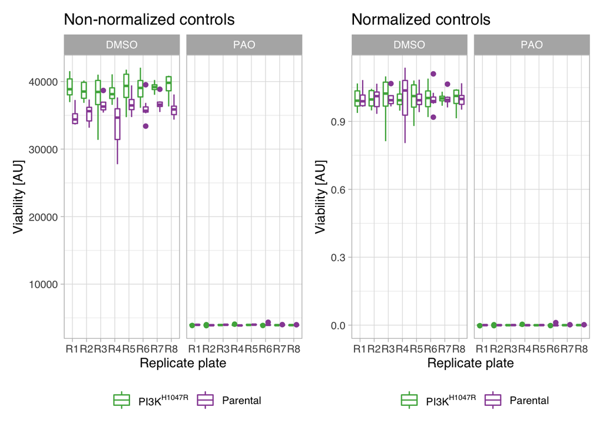

```r
p1 <-
  ggplot(
  filter(df, combo %in% c("DMSO", "PAO")),
  aes(x = replicate, y = viability)
  ) +
  geom_boxplot(aes(color = cell_line)) +
  scale_color_manual(
    name = "",
    values = color_lst,
    labels = label_lst
  ) +
  labs(
    title = "Non-normalized controls",
    x = "Replicate plate",
    y = "Viability [AU]"
  ) +
  facet_wrap(~combo) +
  theme_light(base_family = "Helvetica") +
  theme(legend.position = "bottom")

p2 <- ggplot(
  filter(df, combo %in% c("DMSO", "PAO")),
  aes(x = replicate, y = normalized_viability)
  ) +
  geom_boxplot(aes(color = cell_line)) +
  scale_color_manual(
    name = "",
    values = color_lst,
    labels = label_lst
  ) +
  labs(
    title = "Normalized controls",
    x = "Replicate plate",
    y = "Viability [AU]"
  ) +
  facet_wrap(~combo) +
  theme_light(base_family = "Helvetica") +
  theme(legend.position = "bottom")

p1 + p2
```

The most important test of these validation experiments is if our method can prioritize selective combinations. The box-plot below shows that **combinations that are predicted to be selective are indeed more selective than the control, non-selective combinations** and thus validates model predictions.

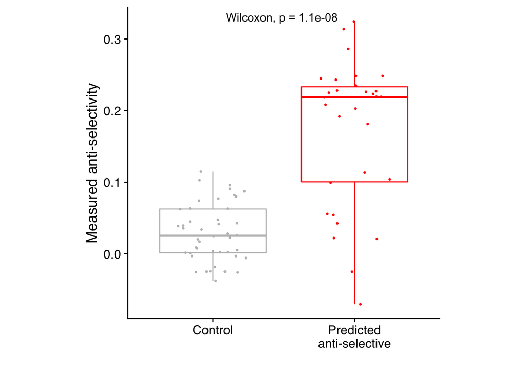

```r
df_sel <- df %>%
  filter(type %in% c("Selective", "NonSelective")) %>%
  select(replicate, cell_line, combo, type, normalized_viability, treatment) %>%
  spread(cell_line, normalized_viability) %>%
  mutate(selectivity = PI3K - WT) %>%
  group_by(combo, treatment, type) %>%
  summarise(selectivity = mean(selectivity))

plt_validation <-
  ggplot(df_sel, aes(x = type, y = selectivity, color = type)) +
  geom_boxplot(outlier.colour = NA) +
  labs(
    x = "",
    y = "Measured anti-selectivity"
  ) +
  scale_color_manual(values = c("gray", "red")) +
  scale_x_discrete(labels = c("Control", "Predicted\nanti-selective")) +
  cowplot::theme_cowplot(font_family = "Helvetica", font_size = 6) +
  theme(legend.position = "none")

plt_validation  +
  geom_jitter(width=0.25, size=0.5) +
  #ggbeeswarm::geom_beeswarm() +
  cowplot::theme_cowplot(font_family = "Helvetica", font_size = 14) +
  theme(aspect.ratio = 1, legend.position = "none") +
  ggpubr::stat_compare_means(method = "wilcox.test", label.x = 1.25)
```

We can also perform a t-test for each individual combination to asses if it is selective.

```r
ttest_combo <-
  df %>%
  filter(type == "Selective") %>%
  select(treatment, cell_line, normalized_viability) %>%
  group_by(treatment) %>%
  mutate(is_partental = cell_line == "WT") %>%
  do(tidy(t.test(.$normalized_viability ~ .$cell_line, alternative = "greater"))) %>%
  arrange(p.value)

ttest_combo %>%
  paged_table()
```

| treatment | estimate | estimate1 | estimate2 | statistic | p.value | parameter | conf.low | conf.high | method | alternative |
| --- | --- | --- | --- | --- | --- | --- | --- | --- | --- | --- |
| GSK3i:3.0 + IGF1Ri:1.2 + PI3Ki:0.14 | 0.28613563 | 0.9303598 | 0.6442242 | 14.4301424 | 5.363854e-10 | 13.753401 | 0.251166269 | Inf | Welch Two Sample t-test | greater |
| GSK3i:3.0 + IGF1Ri:1.2 + mTORi:0.0035 | 0.20272613 | 0.8543641 | 0.6516380 | 11.8042900 | 6.610513e-09 | 13.825763 | 0.172450538 | Inf | Welch Two Sample t-test | greater |
| GSK3i:3.0 + IGF1Ri:1.2 + MEKi:0.00034 | 0.22798407 | 0.9845769 | 0.7565928 | 9.4856085 | 8.957198e-08 | 13.998205 | 0.185651064 | Inf | Welch Two Sample t-test | greater |
| EGFRi:0.015 + IGF1Ri:1.2 + PI3Ki:0.14 | 0.32450361 | 0.9107198 | 0.5862162 | 9.1847668 | 1.676794e-07 | 13.594838 | 0.262144100 | Inf | Welch Two Sample t-test | greater |
| IGF1Ri:1.2 + MEKi:0.00034 + PI3Ki:0.14 | 0.23494821 | 0.9320930 | 0.6971448 | 10.5228149 | 1.985056e-07 | 11.140639 | 0.194896849 | Inf | Welch Two Sample t-test | greater |
| AKTi:0.044 + ERKi:0.00060 + IGF1Ri:1.2 | 0.24302398 | 0.8910677 | 0.6480437 | 9.6373340 | 2.103300e-07 | 12.353234 | 0.198186997 | Inf | Welch Two Sample t-test | greater |
| IGF1Ri:1.2 + MEKi:0.00034 + mTORi:0.0035 | 0.21917918 | 0.9000927 | 0.6809135 | 8.9031186 | 4.830468e-07 | 12.407464 | 0.175422130 | Inf | Welch Two Sample t-test | greater |
| AKTi:0.038 + EGFRi:0.0096 + IGF1Ri:1.2 | 0.19166134 | 0.8605423 | 0.6688809 | 8.1773680 | 9.562016e-07 | 12.838241 | 0.150114134 | Inf | Welch Two Sample t-test | greater |
| AKTi:0.077 + IGF1Ri:1.2 | 0.21828562 | 0.7892813 | 0.5709957 | 7.7089645 | 1.158492e-06 | 13.786180 | 0.168357970 | Inf | Welch Two Sample t-test | greater |
| AKTi:0.054 + IGF1Ri:1.2 + PI3Ki:0.14 | 0.24827883 | 0.7952351 | 0.5469562 | 8.5078470 | 1.512205e-06 | 11.294929 | 0.195995663 | Inf | Welch Two Sample t-test | greater |

[output cut: 20 more lines]

```r
write_tsv(ttest_combo, here("results", "validation", "ttest-combos.tsv"))
```

How many of these are significant? `25`

```r
predictions_control <-
  read_tsv(here("results", "perturbations", "optimization",
                "optimization-selection-control.tsv")) %>%
  select(treatment = AppliedConcentrations,
         WT_predicted = WT,
         PI3K_predicted = PI3K,
         selectivity_predicted = Selectivity) %>%
  mutate(type = "NonSelective")

predictions_selective <-
  read_tsv(here("results", "perturbations", "optimization",
                "optimization-selection-wtselective.tsv")) %>%
  select(treatment = AppliedConcentrations,
         WT_predicted = WT,
         PI3K_predicted = PI3K,
         selectivity_predicted = Selectivity) %>%
  mutate(type = "Selective")

predictions <- bind_rows(predictions_control, predictions_selective)
```

Since IGF1Ri is also selective as a single treatment (cf. pilot data), this raises the question what the added value of the combining it with other drugs is. In other words, are the IGF1Ri + 2-other drugs combinations more selective than IFG1Ri alone?

Let’s first test this over all IGF1Ri containing combinations (and all replicates).

```r
df_igf1r <- df %>%
 filter(
  (n_drugs == 3 & str_detect(combo, "IGF1Ri") & type == "Selective") |
    (n_drugs == 1 & str_detect(combo, "IGF1Ri") & IGF1Ri > 1) # Only use the higher control concentration
  ) %>%
  select(type, replicate, cell_line, combo, type, normalized_viability, treatment) %>%
  spread(cell_line, normalized_viability) %>%
  mutate(selectivity = PI3K - WT)

group_by(df_igf1r, treatment, type) %>%
  summarise(selectivity = mean(selectivity))
```

| treatment | type | selectivity |
| --- | --- | --- |
| AKTi:0.038 + EGFRi:0.0096 + IGF1Ri:1.2 | Selective | 0.1916613 |
| AKTi:0.044 + ERKi:0.00060 + IGF1Ri:1.2 | Selective | 0.2430240 |
| AKTi:0.054 + IGF1Ri:1.2 + PI3Ki:0.14 | Selective | 0.2482788 |
| AKTi:0.065 + IGF1Ri:1.2 + mTORi:0.0035 | Selective | 0.2081893 |
| EGFRi:0.015 + IGF1Ri:1.2 + PI3Ki:0.14 | Selective | 0.3245036 |
| EGFRi:0.018 + IGF1Ri:1.2 + mTORi:0.0035 | Selective | 0.2231865 |
| ERKi:0.0011 + IGF1Ri:1.2 + PI3Ki:0.14 | Selective | 0.3136651 |
| ERKi:0.0013 + IGF1Ri:1.2 + mTORi:0.0035 | Selective | 0.2482776 |
| GSK3i:3.0 + IGF1Ri:1.2 + MEKi:0.00034 | Selective | 0.2279841 |
| GSK3i:3.0 + IGF1Ri:1.2 + mTORi:0.0035 | Selective | 0.2027261 |

[output cut: 8 more lines]

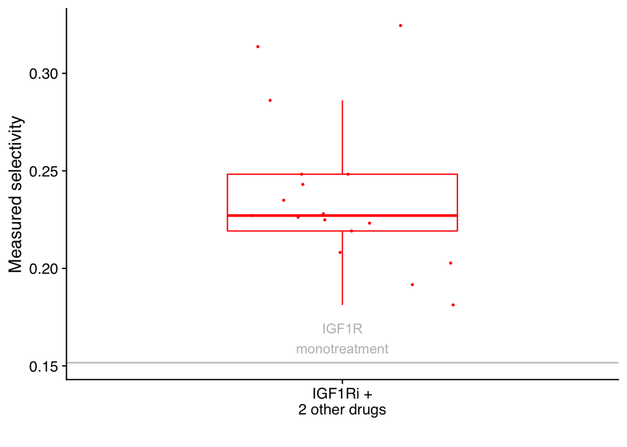

```r
igf1r_mono_sel <- mean(filter(df_igf1r, treatment == "IGF1Ri")$selectivity)

plt_igf1ri_treatments <-
  ggplot(
    filter(df_igf1r, type == "Selective") %>%
      group_by(type, treatment) %>%
      summarise(selectivity = mean(selectivity)),
  aes(x = type, y = selectivity)
  ) +
  geom_boxplot(outlier.colour = NA, color = "red", width=0.5) +
  geom_hline(yintercept = igf1r_mono_sel, color = "gray") +
  labs(
    #title = "All IGF1Ri-containing treatments",
    x = "",
    y = "Measured selectivity"
  ) +
  scale_x_discrete(
    labels = c("SingleDrugControl" = "IGF1Ri\nonly",  "Selective" = "IGF1Ri +\n2 other drugs"),
    )
plt_igf1ri_treatments +
  geom_jitter(width = 0.25, size = 0.5, color = "red") +
  cowplot::theme_cowplot(font_family = "Helvetica", font_size = 14) +
  theme(legend.position = "None") +
  annotate(geom="text", x = 1, y=igf1r_mono_sel + 0.0125, label="IGF1R\nmonotreatment", color="gray")
```

What is the one-samnple t-test comparing IGF1Ri alone to IGF1R in combo?

```r
tmp <- df_igf1r %>%
  group_by(type, treatment) %>%
  summarise(WT = mean(WT), PI3K = mean(PI3K)) %>%
  mutate(selectivity = PI3K - WT)
t.test(
  filter(tmp, type == "Selective")$selectivity,
  mu = filter(tmp, type == "SingleDrugControl")$selectivity,
  alternative = "greater"
  )
```

```
##
##  One Sample t-test
##
## data:  filter(tmp, type == "Selective")$selectivity
## t = 9.034, df = 16, p-value = 5.536e-08
## alternative hypothesis: true mean is greater than 0.1516372
## 95 percent confidence interval:
##  0.2206096       Inf
## sample estimates:
## mean of x
## 0.2371321
```

The boxplot above clearly indicates that **IGF1Ri in combination with selected other drugs is more selective than IGF1Ri alone.**

However, in this case it makes more sense to look at a per-combinations basis. (Now, we use a one-sided t-test instead of wilcoxon because we’re not combining different combinations, only comparing replicates.)

```r
ttest_igf1r_combos <- df_igf1r %>%
  filter(type != "SingleDrugControl") %>%
  left_join(
    select(
      filter(df_igf1r, type == "SingleDrugControl"),
      replicate, control_selectivity = selectivity
      ),
    by = "replicate"
  ) %>%
  group_by(combo) %>%
  do(tidy(t.test(.$selectivity, .$control_selectivity, alternative  = "greater"))) %>%
  ungroup() %>%
  arrange(p.value) %>%
  mutate(rank = dense_rank(desc(estimate)))

ttest_igf1r_combos %>%
  select(combo, estimate, p.value) %>%
  paged_table()
```

| combo | estimate | p.value |
| --- | --- | --- |
| EGFRi+IGF1Ri+PI3Ki | 0.17286637 | 0.0001605427 |
| ERKi+IGF1Ri+PI3Ki | 0.16202790 | 0.0006872766 |
| GSK3i+IGF1Ri+PI3Ki | 0.13449840 | 0.0007827647 |
| ERKi+IGF1Ri+mTORi | 0.09664041 | 0.0061575193 |
| AKTi+ERKi+IGF1Ri | 0.09138675 | 0.0125954836 |
| AKTi+IGF1Ri+PI3Ki | 0.09664159 | 0.0139280338 |
| IGF1Ri+MEKi+PI3Ki | 0.08331097 | 0.0249124656 |
| IGF1Ri+mTORi+RAFi | 0.07544796 | 0.0266560634 |
| GSK3i+IGF1Ri+MEKi | 0.07634683 | 0.0327114681 |
| IGF1Ri+PI3Ki+RAFi | 0.07327028 | 0.0382633634 |

[output cut: 7 more lines]

```r
write_tsv(ttest_igf1r_combos, here("results", "validation", "ttest-igf1ri-mono-vs-combo.tsv"))
```

**11 out of 17 IGF1Ri-containing combinations individually show a statistically significant greater selectivity than IGF1Ri treatment alone** at a comparable concentration.

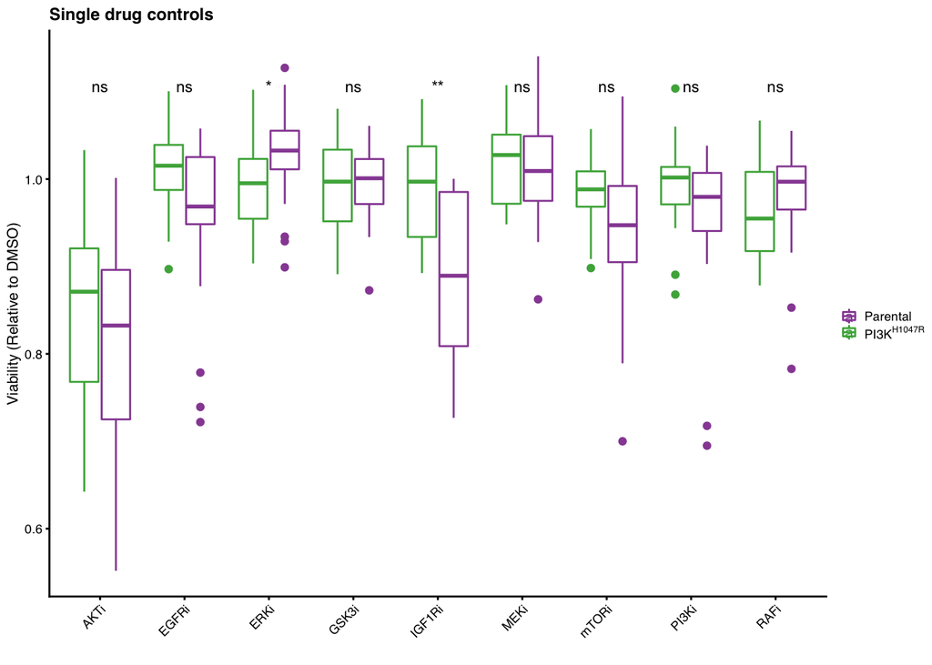

```r
df %>%
  filter(type == "SingleDrugControl") %>%
  ggplot(aes(x = combo, y = normalized_viability, color = cell_line)) +
  geom_boxplot() +
  scale_color_manual(
    name = "", breaks = c("WT", "PI3K"),
    values = color_lst,
    labels = label_lst
  ) +
  labs(
    title = "Single drug controls",
    y = "Viability (Relative to DMSO)",
    x = ""
  ) +
  cowplot::theme_cowplot(font_family = "Helvetica", font_size = 8) +
  theme(axis.text.x = element_text(angle = 45, hjust = 1)) +
  ggpubr::stat_compare_means(
    method = "wilcox.test", label.x = 1.5, label.y = 1.1,
    size = 3, label = 'p.signif')
```

Finally, let’s visualize the most selective combinations.

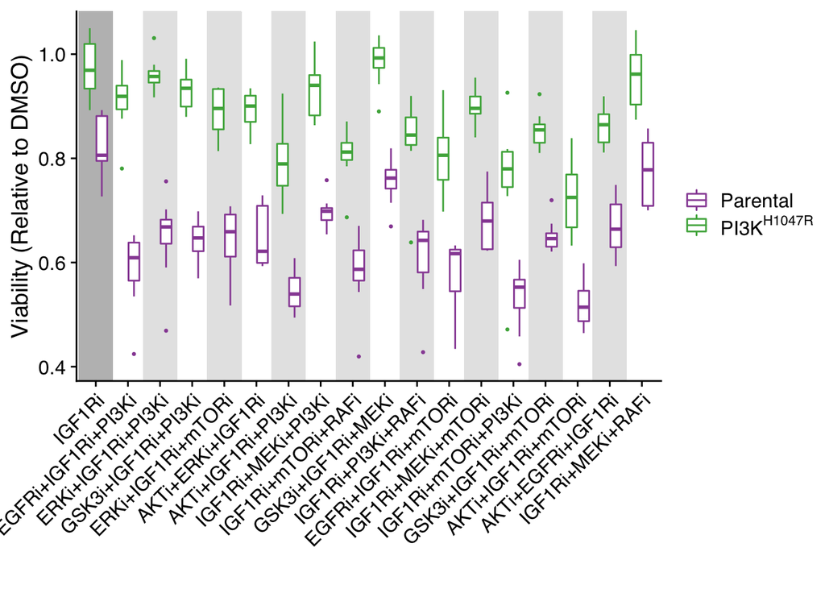

```r
combos_to_plot <-
  ttest_igf1r_combos %>%
  arrange(desc(conf.low)) %>%
  #head(n = 8) %>%
  pull(combo)

background_col <- "gray90"

plt_top_combos <-
  df_igf1r %>%
  filter(combo %in% c("IGF1Ri", combos_to_plot)) %>%
  left_join(ttest_igf1r_combos, by = "combo") %>%
  select(replicate, combo, PI3K, WT, rank) %>%
  gather(cell_line, viability, WT, PI3K) %>%
  ggplot(
  aes(x = combo, y = viability, color = cell_line)
  ) +
  geom_rect(xmin=0.5, xmax=1.5, ymin=-Inf, ymax=+Inf, fill = "gray", color = "gray") +
  geom_rect(xmin=2.5, xmax=3.5, ymin=-Inf, ymax=+Inf, fill = background_col, color = background_col) +
  geom_rect(xmin=4.5, xmax=5.5, ymin=-Inf, ymax=+Inf, fill = background_col, color = background_col) +
  geom_rect(xmin=6.5, xmax=7.5, ymin=-Inf, ymax=+Inf, fill = background_col, color = background_col) +
  geom_rect(xmin=8.5, xmax=9.5, ymin=-Inf, ymax=+Inf, fill = background_col, color = background_col) +
  geom_rect(xmin=10.5, xmax=11.5, ymin=-Inf, ymax=+Inf, fill = background_col, color = background_col) +
  geom_rect(xmin=12.5, xmax=13.5, ymin=-Inf, ymax=+Inf, fill = background_col, color = background_col) +
  geom_rect(xmin=14.5, xmax=15.5, ymin=-Inf, ymax=+Inf, fill = background_col, color = background_col) +
  geom_rect(xmin=16.5, xmax=17.5, ymin=-Inf, ymax=+Inf, fill = background_col, color = background_col) +
  geom_boxplot(outlier.size = 0.5) +
  scale_x_discrete(limits = c("IGF1Ri", combos_to_plot)) +
  scale_color_manual(
    name = "", breaks = c("WT", "PI3K"),
    values = color_lst,
    labels = label_lst
  ) +
  labs(
    #title = "Selective combinations",
    y = "Viability (Relative to DMSO)",
    x = ""
  ) +
  cowplot::theme_cowplot(font_family = "Helvetica") +
  theme(axis.text.x = element_text(angle = 45, hjust = 1))

plt_top_combos
```